# SQ 023

## Shared Qs (023)

#### Question

1. A right triangle has an angle of 1.19 radians. The hypotenuse has a length of 41 meters. How long, in meters, is the leg opposite the angle?

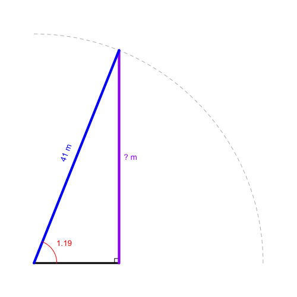

   Please round your answer to the nearest meter.

#### Question

2. A right triangle has an angle of 0.64 radians. The hypotenuse has a length of 47 meters. How long, in meters, is the leg opposite the angle?

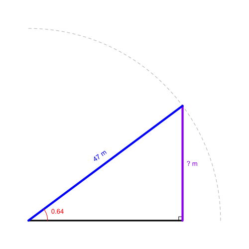

   Please round your answer to the nearest meter.

#### Question

3. A right triangle has an angle of 0.57 radians. The hypotenuse has a length of 29 meters. How long, in meters, is the leg opposite the angle?

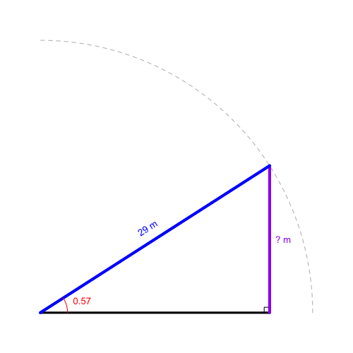

   Please round your answer to the nearest meter.

#### Question

4. A right triangle has an angle of 0.97 radians. The hypotenuse has a length of 86 meters. How long, in meters, is the leg opposite the angle?

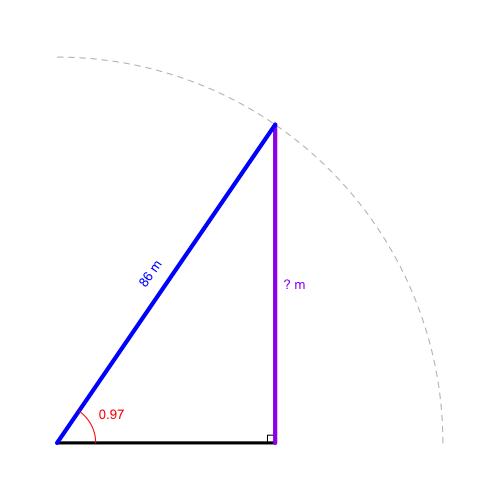

   Please round your answer to the nearest meter.

#### Question

5. A right triangle has an angle of 0.88 radians. The hypotenuse has a length of 76 meters. How long, in meters, is the leg opposite the angle?

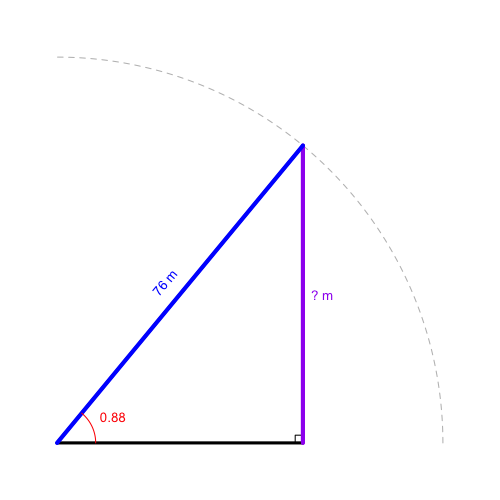

   Please round your answer to the nearest meter.

#### Question

6. A right triangle has an angle of 1.19 radians. The hypotenuse has a length of 80 meters. How long, in meters, is the leg opposite the angle?

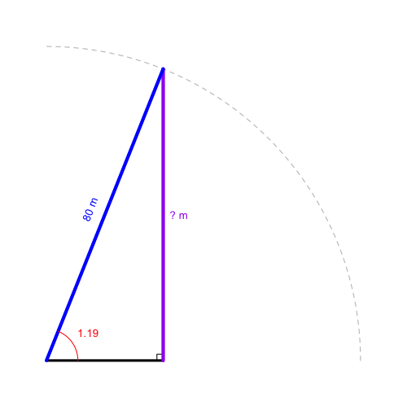

   Please round your answer to the nearest meter.

#### Question

7. A right triangle has an angle of 0.95 radians. The hypotenuse has a length of 16 meters. How long, in meters, is the leg opposite the angle?

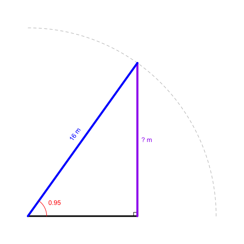

   Please round your answer to the nearest meter.

#### Question

8. A right triangle has an angle of 0.53 radians. The hypotenuse has a length of 95 meters. How long, in meters, is the leg opposite the angle?

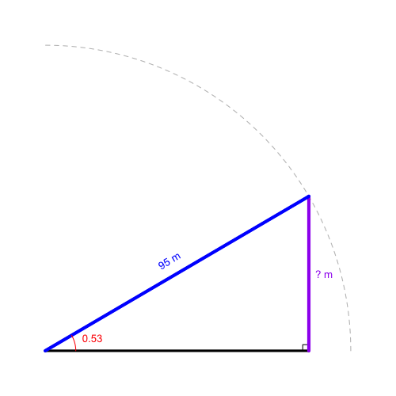

   Please round your answer to the nearest meter.

#### Question

9. A right triangle has an angle of 0.89 radians. The hypotenuse has a length of 48 meters. How long, in meters, is the leg opposite the angle?

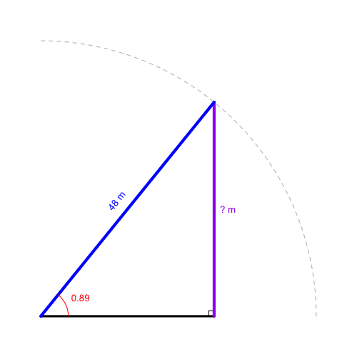

   Please round your answer to the nearest meter.

#### Question

10. A right triangle has an angle of 0.93 radians. The hypotenuse has a length of 23 meters. How long, in meters, is the leg opposite the angle?

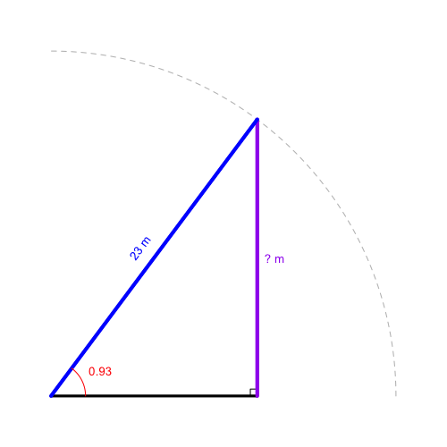

    Please round your answer to the nearest meter.

#### Question

11. A right triangle has an angle of 0.64 radians. The opposite leg has a length of 48 meters. How long, in meters, is the hypotenuse?

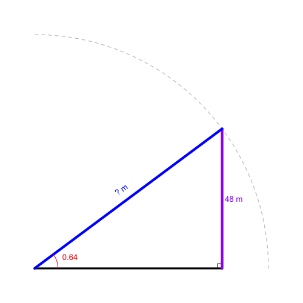

    Please round your answer to the nearest meter.

#### Question

12. A right triangle has an angle of 0.57 radians. The opposite leg has a length of 53 meters. How long, in meters, is the hypotenuse?

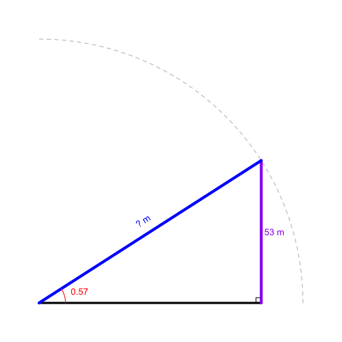

    Please round your answer to the nearest meter.

#### Question

13. A right triangle has an angle of 0.49 radians. The opposite leg has a length of 33 meters. How long, in meters, is the hypotenuse?

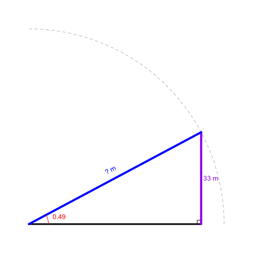

    Please round your answer to the nearest meter.

#### Question

14. A right triangle has an angle of 0.57 radians. The opposite leg has a length of 53 meters. How long, in meters, is the hypotenuse?

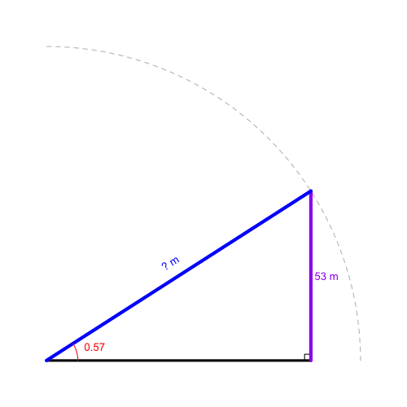

    Please round your answer to the nearest meter.

#### Question

15. A right triangle has an angle of 0.87 radians. The opposite leg has a length of 64 meters. How long, in meters, is the hypotenuse?

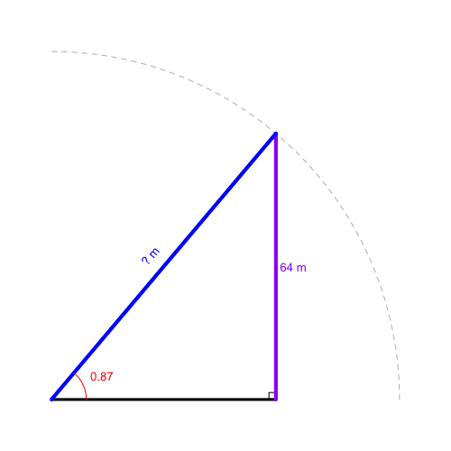

    Please round your answer to the nearest meter.

#### Question

16. A right triangle has an angle of 0.98 radians. The opposite leg has a length of 45 meters. How long, in meters, is the hypotenuse?

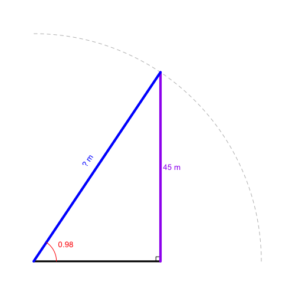

    Please round your answer to the nearest meter.

#### Question

17. A right triangle has an angle of 0.69 radians. The opposite leg has a length of 16 meters. How long, in meters, is the hypotenuse?

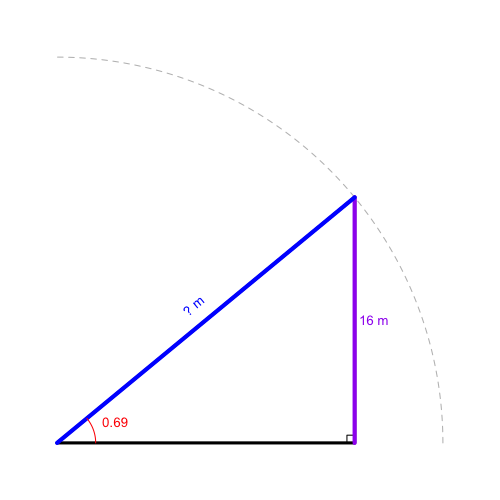

    Please round your answer to the nearest meter.

#### Question

18. A right triangle has an angle of 0.85 radians. The opposite leg has a length of 25 meters. How long, in meters, is the hypotenuse?

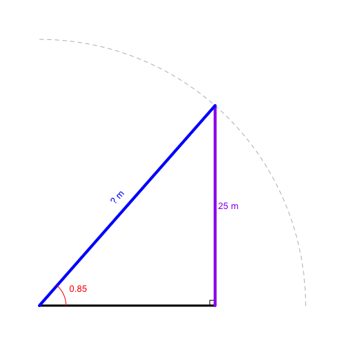

    Please round your answer to the nearest meter.

#### Question

19. A right triangle has an angle of 1.22 radians. The opposite leg has a length of 37 meters. How long, in meters, is the hypotenuse?

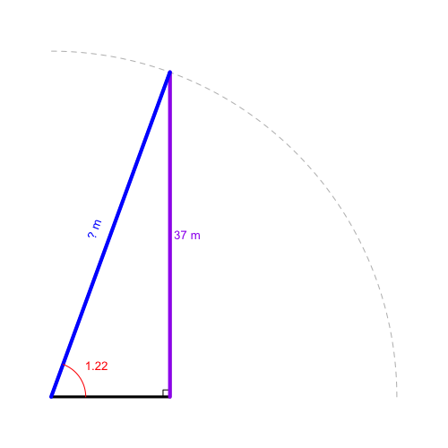

    Please round your answer to the nearest meter.

#### Question

20. A right triangle has an angle of 0.98 radians. The opposite leg has a length of 22 meters. How long, in meters, is the hypotenuse?

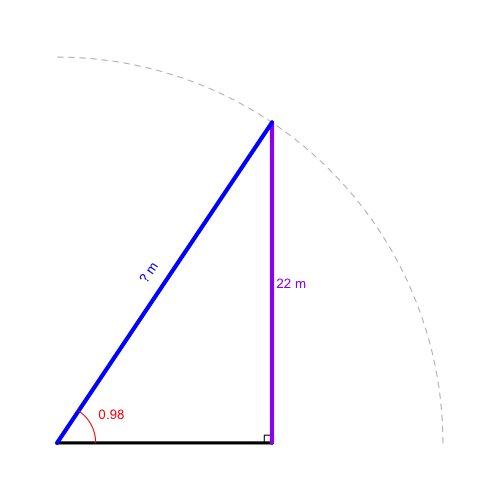

    Please round your answer to the nearest meter.

#### Question

21. A right triangle has an angle measure $\theta$. The opposite leg’s length is 37 meters, and the hypotenuse’s length is 51 meters. What is the angle measure $\theta$ in radians?

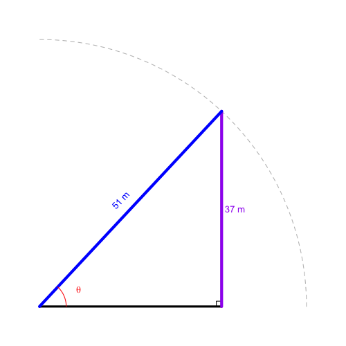

    Please round your answer to the hundredth of a radian.

#### Question

22. A right triangle has an angle measure $\theta$. The opposite leg’s length is 36 meters, and the hypotenuse’s length is 64 meters. What is the angle measure $\theta$ in radians?

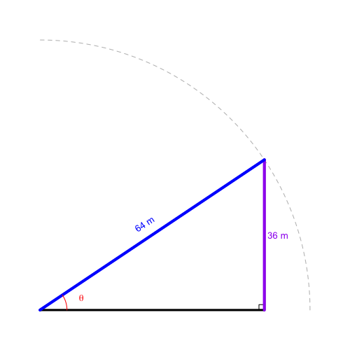

    Please round your answer to the hundredth of a radian.

#### Question

23. A right triangle has an angle measure $\theta$. The opposite leg’s length is 79 meters, and the hypotenuse’s length is 83 meters. What is the angle measure $\theta$ in radians?

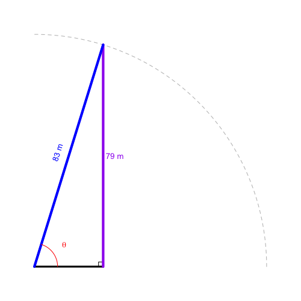

    Please round your answer to the hundredth of a radian.

#### Question

24. A right triangle has an angle measure $\theta$. The opposite leg’s length is 29 meters, and the hypotenuse’s length is 60 meters. What is the angle measure $\theta$ in radians?

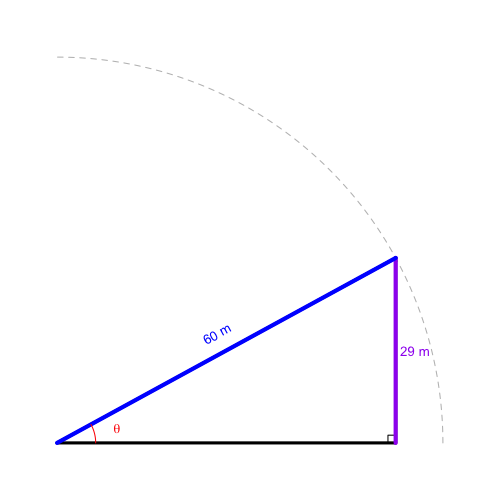

    Please round your answer to the hundredth of a radian.

#### Question

25. A right triangle has an angle measure $\theta$. The opposite leg’s length is 45 meters, and the hypotenuse’s length is 66 meters. What is the angle measure $\theta$ in radians?

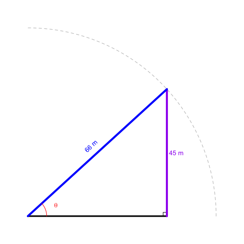

    Please round your answer to the hundredth of a radian.

#### Question

26. A right triangle has an angle measure $\theta$. The opposite leg’s length is 47 meters, and the hypotenuse’s length is 53 meters. What is the angle measure $\theta$ in radians?

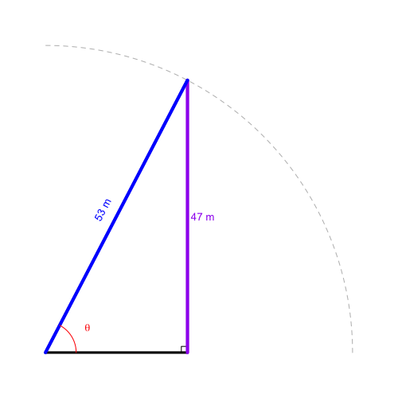

    Please round your answer to the hundredth of a radian.

#### Question

27. A right triangle has an angle measure $\theta$. The opposite leg’s length is 42 meters, and the hypotenuse’s length is 47 meters. What is the angle measure $\theta$ in radians?

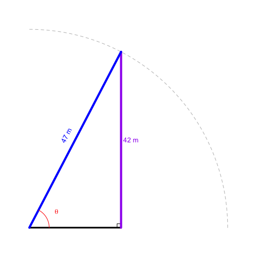

    Please round your answer to the hundredth of a radian.

#### Question

28. A right triangle has an angle measure $\theta$. The opposite leg’s length is 26 meters, and the hypotenuse’s length is 36 meters. What is the angle measure $\theta$ in radians?

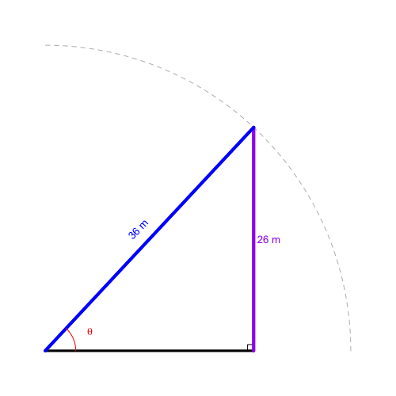

    Please round your answer to the hundredth of a radian.